# Tarea_04_2025

Julieta González

2025-04-12

# Tarea 4

## (20 %) Preguntas rápidas (simples)

1. Considera una red de 15 nodos . Considera que tienes una sola conexión. ¿Cuál es el número máximo de nodos que puedes conectar? Dado un solo nodo , ¿cuál es el número máximo conexiones que puede tener tal nodo?

Puesto que sólo hay una conexión, esta entonces une a dos nodos, por lo que el número máximo de nodos que se pueden conectar es 2 (A->B). El número máximo de conexiones que puede tener un nodo no puede ser mayor al número de nodos total, por lo que el número máximo que puede tener un nodo en este caso es de 15-1 = 14; 14 nodos.

2. Considera una red dirigida de 10 nodos. Usa 25 conexiones y dibuja una red con ese número de nodos y conexiones dirigidas. Calcula la distribución de conectividades de salida.Calcula el número total de conexiones de salida ¿Cómo se compara el número total de de conectividades de entrada (son iguales, diferentes)? Explica tu respuesta. Calcula el promedio de entrada y de salida. Discute tu resultado.

```r
g <- make_empty_graph ( n= 10, directed = TRUE)

conex <- sample(1:10, 50, replace = TRUE) #para 25 conexiones necesito 50 números, porque van en pares
conex
```

```
##  [1]  7  1  8  1  7  3  5  9  5 10 10  9  7  7  5  8  5 10  8  2  4  9  4  3  8
## [26]  1  4  9  9  9  4  6  5  4  8  5 10  2  3  5  1  3  2  6  6  8  4  9  4 10
```

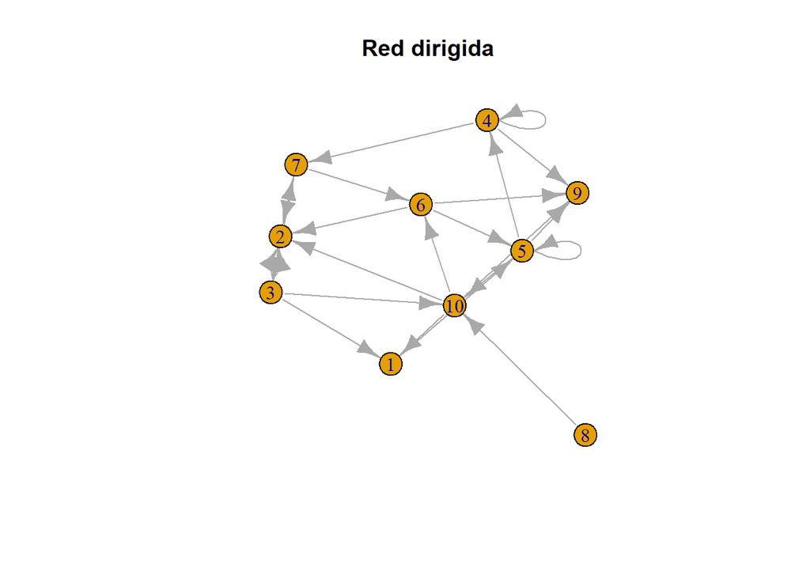

```r
#le pedía a la IA que les pusiera coma entre los 50 números para volverlos a guardar en el vector
conex <- c(7, 6, 10, 2, 7, 2, 6, 5, 8, 10, 4, 9, 10, 6, 4, 7, 2, 7, 3, 2, 6, 9, 5, 5, 6, 2, 3, 10, 7, 3, 5, 4, 4, 4, 10, 9, 2, 3, 3, 1, 5, 9, 1, 5, 5, 10, 3, 2, 10, 1)
g <- add_edges (g, conex)
plot(g, main = "Red dirigida")
```

```r
d <- degree(g, mode = "in")
mean(d)
```

```
## [1] 2.5
```

```r
d2 <- degree(g, mode = "out")
mean(d2)
```

```
## [1] 2.5
```

Para los promedios de grado de salida y entrada se obtuvo un valor de 2.5. Esto sucede porque al tener 25 conexiones, el número total del grado es 25. Entonces hay 25 conexiones “salientes” (out) y 25 “entrantes” (in), y como hay 10 nodos, lo que se hace para calcular la media es 25/10, que es igual a 2.5. Aunque en primeria instancia se podría pensar que los loops hacia su mismo nodo afectan el degree de entrada y salida de un nodo, en este caso el promedio se mantuvo estable incluso con la presencia de estos. Los self-loops pueden afectar el grado del nodo de origen al agregarle +1 para el grado in y out, y dependiendo del contexto, estos deben o no ser removidos, como en el caso de la red de amigos, donde se tuvieron que remover los self-loops generados por aquellos que se eligieron como su propio amigo.

3. Considera una red no dirigida de $n=3,4,5,6$ nodos respectivamente. ¿Cuál es el número máximo de conexiones que puedes poner? Dibuja cada caso. ¿Qué pasa si la red es dirigida?

El número máximo de conexiones que se puede poner sin que un nodo se diriga a sí mismo es calculado mediante k(k-1)/2.

```r
max_conex <- function (x) { #x representa el número de nodos
    max <- (x*(x-1))/2
  return (max) #
}

#Máximo número de conexiones posibles
max_conex(3)
```

```
## [1] 3
```

```r
max_conex(4)
```

```
## [1] 6
```

```r
max_conex(5)
```

```
## [1] 10
```

```r
max_conex(6)
```

```
## [1] 15
```

*No puede añadir el dibujo, pero está en la carpeta de Ejercicios como dibujo.png* En su lugar añado el código:

```
## Número de nodos: 3
## Máximo número de conexiones para una red de 3 nodos: 3
```

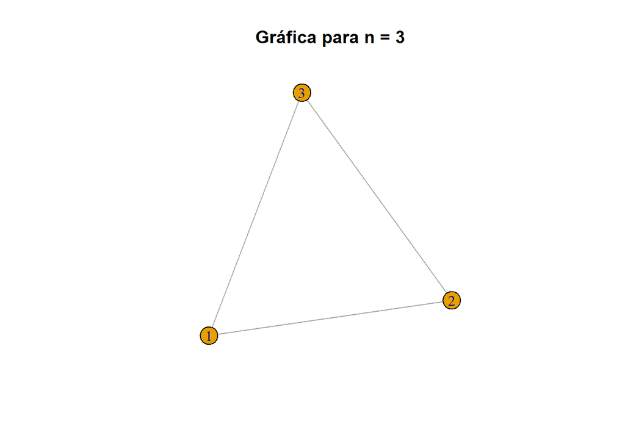

```
## Número de nodos: 4
## Máximo número de conexiones para una red de 4 nodos: 6
```

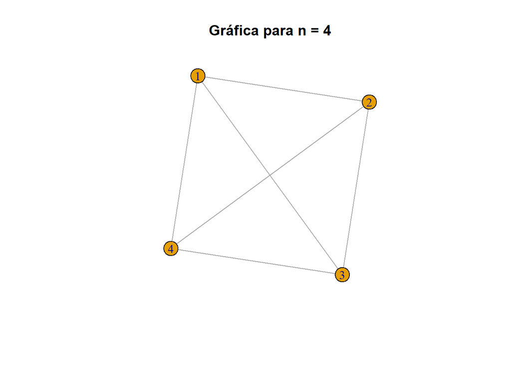

```
## Número de nodos: 5
## Máximo número de conexiones para una red de 5 nodos: 10
```

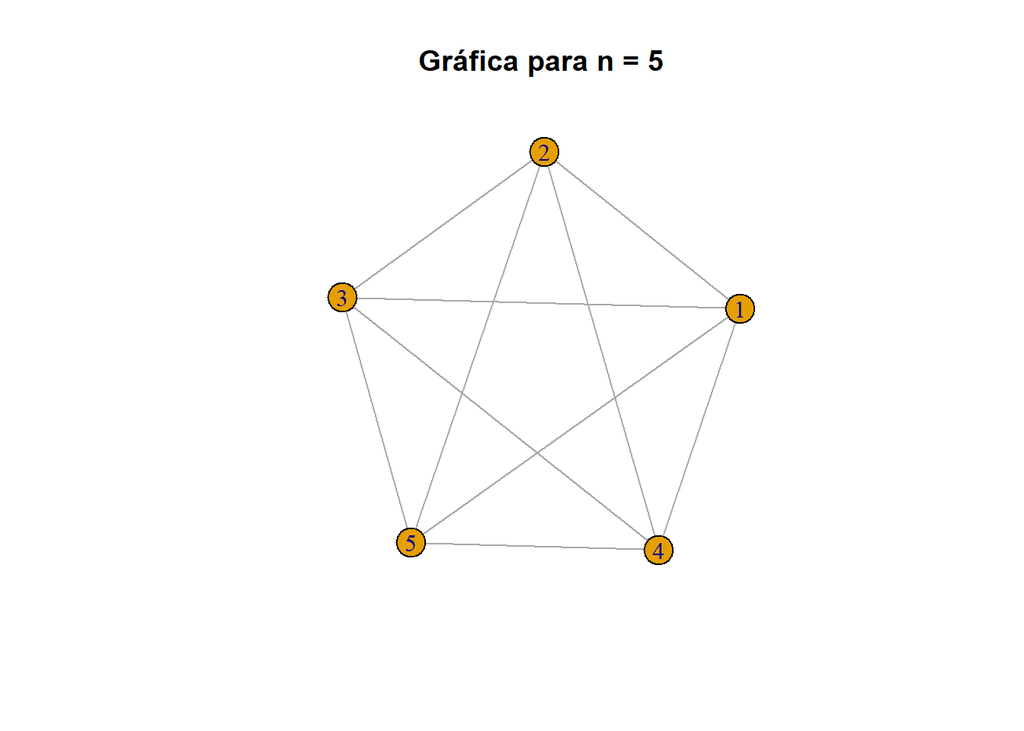

```
## Número de nodos: 6
## Máximo número de conexiones para una red de 6 nodos: 15
```

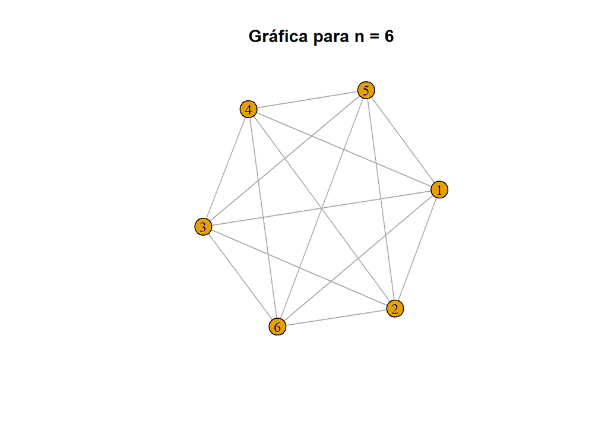

```r
for (i in 3:6) {
  gr <- make_full_graph(i, directed = FALSE)
  cat("Número de nodos:", i, "\n")
  cat("Máximo número de conexiones para una red de", i, "nodos:", max_conex(i), "\n")
  plot(gr, main = paste("Gráfica para n =", i))
}
```

En caso de tratarse de redes dirigidas, el número de conexiones máximas se vería modificado, mostrando un aumento ya que al añadirle una conexión dirigida, se estaría adicionando un enlace por cada par de nodos en cada dirección, por lo que el número de conexiones máximas aumenta. Esto ejemplifica la naturaleza simétrica de las redes no dirigidas y la asimetría en las dirigidas, pues las redes no dirigidas sugieren nua relación mutua en la unión de los nodos, muestras que en las dirigidas existe una dirección específica donde existe un flujo.

```
## Máximo número de conexiones para una red de 3 nodos
```

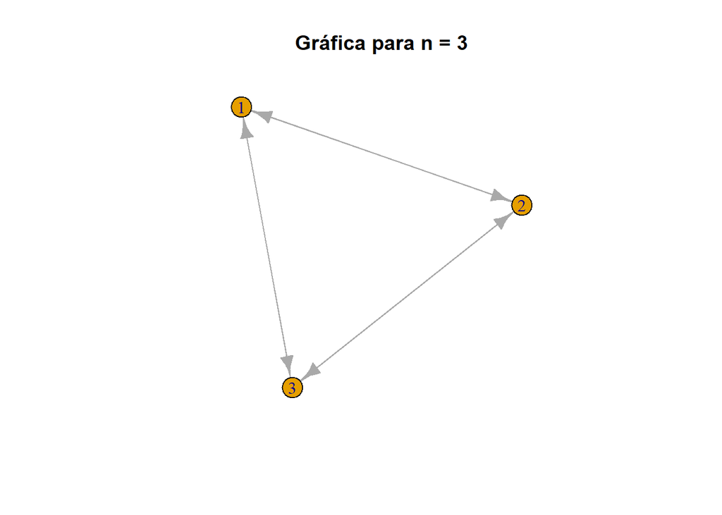

```
## Máximo número de conexiones para una red de 6 nodos
```

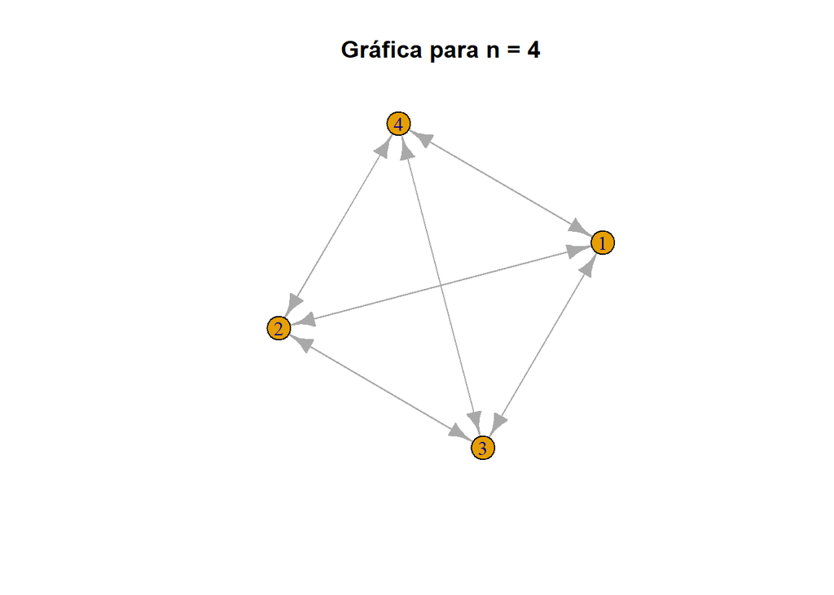

```
## Máximo número de conexiones para una red de 10 nodos
```

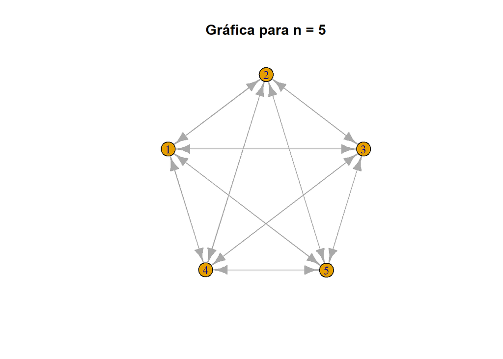

```
## Máximo número de conexiones para una red de 15 nodos
```

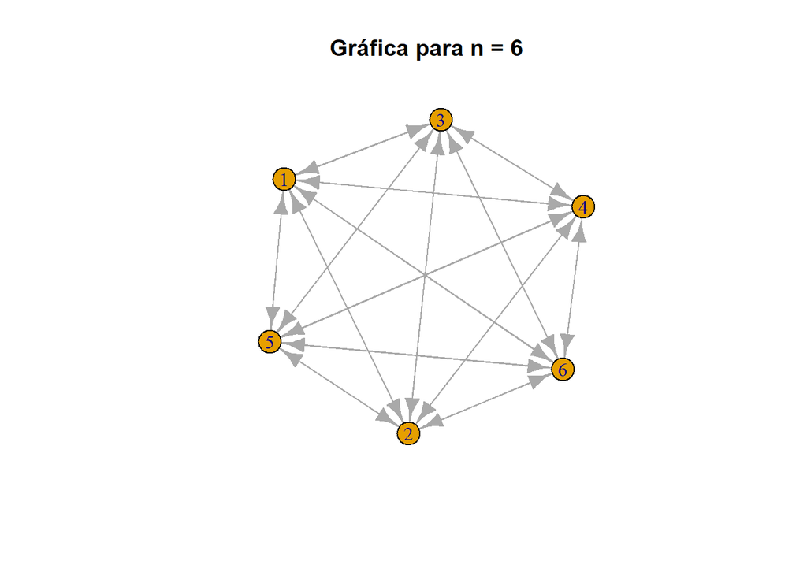

```r
for (i in 3:6) {
  gr <- make_full_graph (i, directed = TRUE)
  cat ("Máximo número de conexiones para una red de", max_conex(i), "nodos", "\n")
  plot(gr, main = paste ("Gráfica para n =", i))
}
```

4. Considera tu red de amigos reales. ¿Cuál es tu coeficiente de clusterización? Mi coeficiente de clusterización en la red de amigos reales se referiría a cuáles de mis amigos son amigos entre sí. Este sería mucho menor al calculado en la red de amigos, ya que, a diferencia de la escuela, las distintas personas con las que socializamos pertenecen a diferentes entornos donde no tienen la oportunidad de convivir entre sí.

## (80 % ) Scripts, código, texto y gráficas

1. **Propiedades básicas de redes**

A partir de las siguientes redes calcula manualmente las siguientes propiedades de cada red

- Número de conexiones
- Número de nodos
- Degree
- Average degree
- Degree distribution
- Density
- Adjacency matrix
- Matriz de distancia
- Diámetro
- Nodos más distantes
- Coeficiente de clusterización

Después escribe código en R que genere las gráficas de las redes y que calcule las propiedades anteriores para cada red.

*Ejercicios a mano se encuentran en la carpeta ejercicios dentro del pdf con el mismo nombre*

```r
# Gráficas
ag <-  make_graph(edges = c(1,7, 2,1, 2,3, 3,5, 4,2, 4,8, 6,4, 6,9, 6,10), directed = FALSE)
bg <- make_graph (edges = c (2,1, 3,1, 4,1, 5,1, 6,1, 7,4, 8,4, 9,4, 10,8), directed = TRUE )
cg <- make_full_graph (10, directed = FALSE)
dg <- make_graph (edges = c (1,3, 1,8, 2,4, 2,5, 2,6, 2,10, 3,10, 4,1, 4,2, 4,3, 4,6, 4,9, 4,10, 5,1, 5,7, 5,10, 6,3, 6,8, 6,9, 7,1, 7,8, 8,7, 8,9, 8,10, 9,2, 9,3, 9,6, 9,10, 10,1, 10,5, 10,6, 10,9))
eg <- make_graph (edges = c(1,10, 2,7, 3,1, 3,7, 5,7, 6,4, 7,1, 7,8, 8,6, 8,9, 8,10, 9,10, 10,4), directed = FALSE)
fg <- make_graph(edges = c(1,2, 1,3, 2,4, 2,5, 3,6, 3,7, 4,8, 4,9, 5,10), directed = TRUE)
```

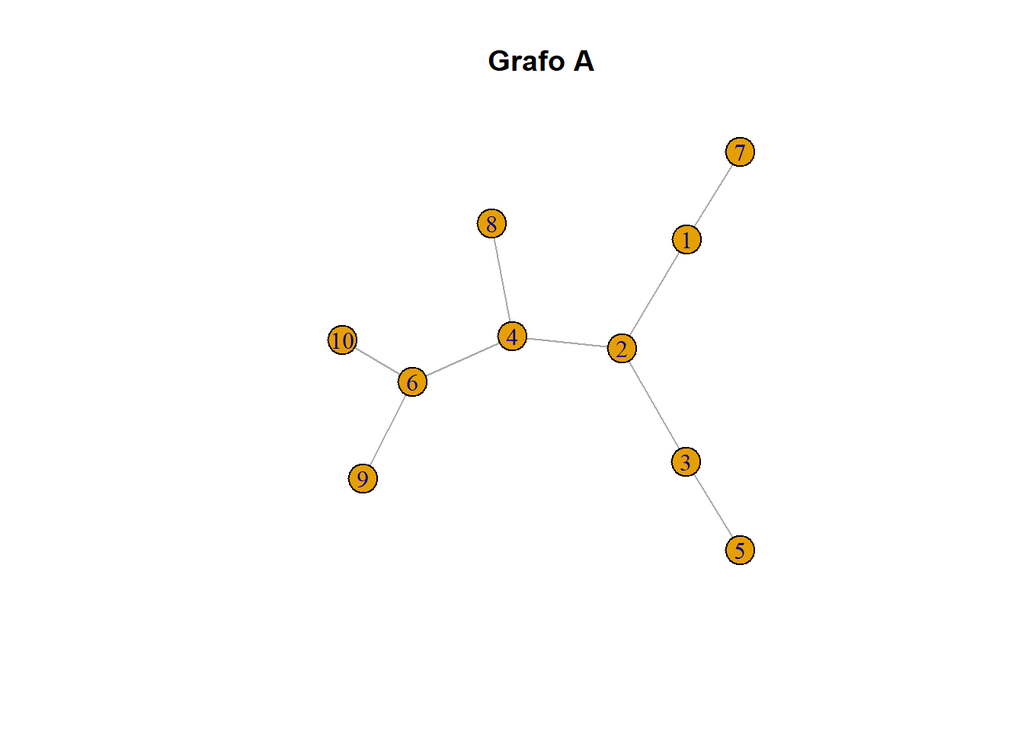

```r
#Graficar
plot(ag, main = "Grafo A")
```

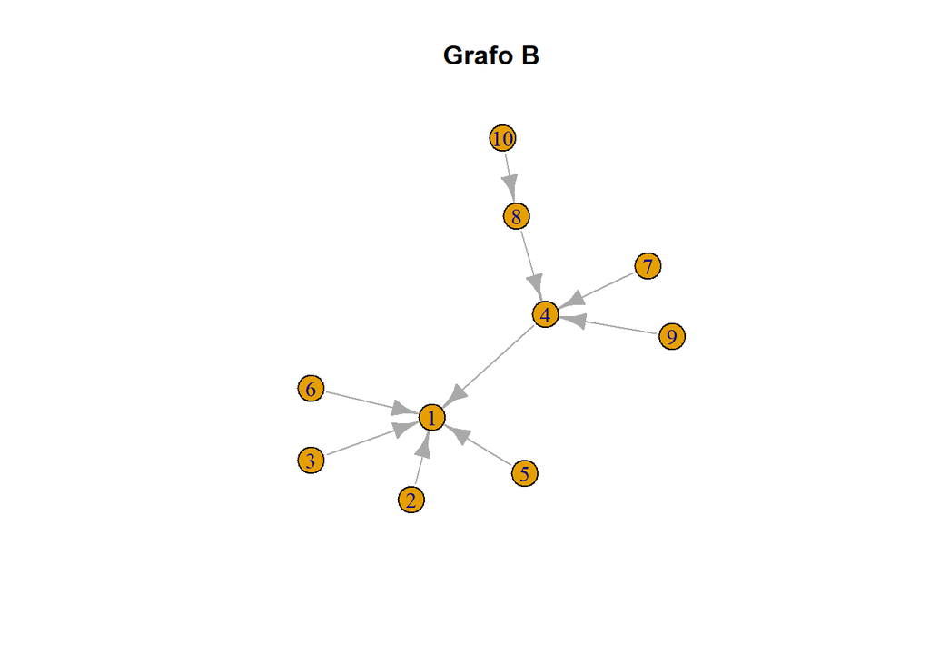

```r
plot(bg, main = "Grafo B")
```

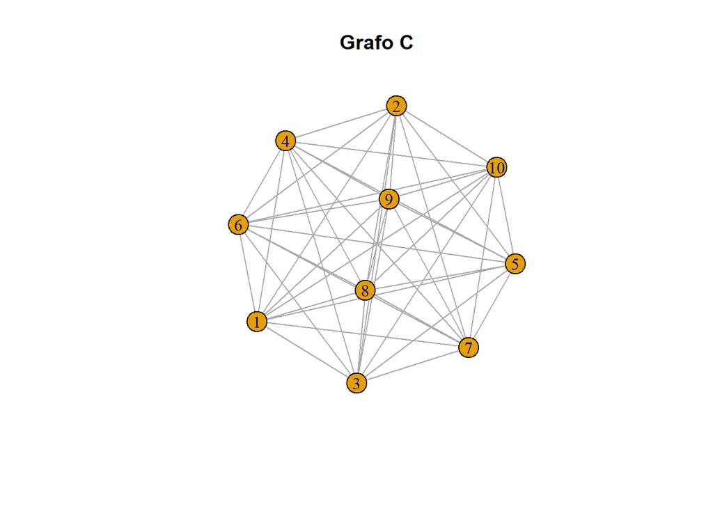

```r
plot(cg, main = "Grafo C")
```

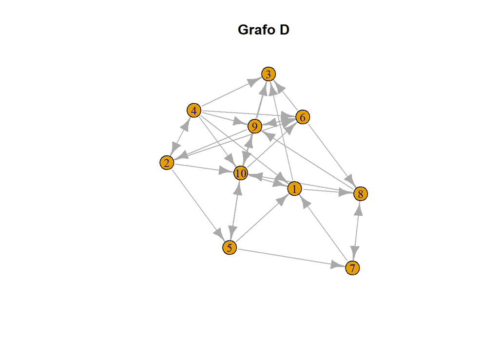

```r
plot(dg, main = "Grafo D")
```

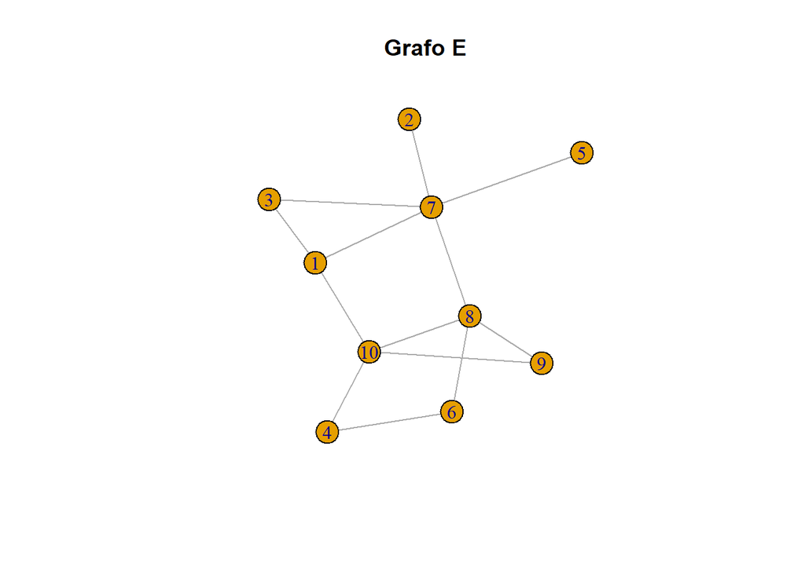

```r
plot(eg, main = "Grafo E")
```

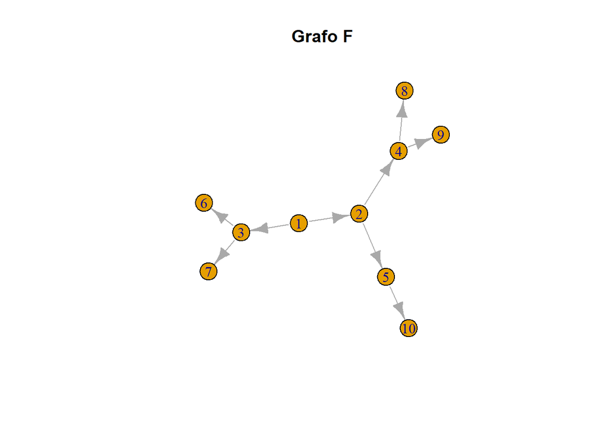

```r
plot(fg, main = "Grafo F")
```

```r
#Propiedades
prop_graf <- function(grafica) {
  num_nodos <- vcount(grafica)
  num_conexiones <- ecount(grafica)
  grados <- degree(grafica, mode = "all")
  promedio_grado <- mean(grados)
  distribucion_grado <- degree_distribution(grafica, mode = "all")
  densidad <- edge_density(grafica)
  diametro <- diameter(grafica)
  nodos_distantes <- get_diameter(grafica)
  cc <- transitivity(grafica, type = "local")

  cat("Nodos:", num_nodos, "\n")
  cat("Conexiones:", num_conexiones, "\n")
  cat("Promedio degree:", promedio_grado, "\n")
  cat("Densidad:", densidad, "\n")
  cat("Diámetro:", diametro, "\n")
  cat("Nodos distantes:", nodos_distantes, "\n")
  cat("Coeficiente de clusterización promedio:", cc, "\n")
}

#Evaluar gráficas

#Gráfico A
prop_graf(ag)
```

```
## Nodos: 10
## Conexiones: 9
## Promedio degree: 1.8
## Densidad: 0.2
## Diámetro: 5
## Nodos distantes: 5 3 2 4 6 9
## Coeficiente de clusterización promedio: 0 0 0 0 NaN 0 NaN NaN NaN NaN
```

```r
  #Matrices por separado
m_ag <- as.matrix(as_adjacency_matrix(ag))
m_ag
```

```
##       [,1] [,2] [,3] [,4] [,5] [,6] [,7] [,8] [,9] [,10]
##  [1,]    0    1    0    0    0    0    1    0    0     0
##  [2,]    1    0    1    1    0    0    0    0    0     0
##  [3,]    0    1    0    0    1    0    0    0    0     0
##  [4,]    0    1    0    0    0    1    0    1    0     0
##  [5,]    0    0    1    0    0    0    0    0    0     0
##  [6,]    0    0    0    1    0    0    0    0    1     1
##  [7,]    1    0    0    0    0    0    0    0    0     0
##  [8,]    0    0    0    1    0    0    0    0    0     0
##  [9,]    0    0    0    0    0    1    0    0    0     0
## [10,]    0    0    0    0    0    1    0    0    0     0
```

```r
md_ag <- distances(ag)
md_ag
```

```
##       [,1] [,2] [,3] [,4] [,5] [,6] [,7] [,8] [,9] [,10]
##  [1,]    0    1    2    2    3    3    1    3    4     4
##  [2,]    1    0    1    1    2    2    2    2    3     3
##  [3,]    2    1    0    2    1    3    3    3    4     4
##  [4,]    2    1    2    0    3    1    3    1    2     2
##  [5,]    3    2    1    3    0    4    4    4    5     5
##  [6,]    3    2    3    1    4    0    4    2    1     1
##  [7,]    1    2    3    3    4    4    0    4    5     5
##  [8,]    3    2    3    1    4    2    4    0    3     3
##  [9,]    4    3    4    2    5    1    5    3    0     2
## [10,]    4    3    4    2    5    1    5    3    2     0
```

```r
#A excepción de los nodos distantes, matrices y datos coinciden


#Gráfico B
prop_graf(bg)
```

```
## Nodos: 10
## Conexiones: 9
## Promedio degree: 1.8
## Densidad: 0.1
## Diámetro: 3
## Nodos distantes: 10 8 4 1
## Coeficiente de clusterización promedio: 0 NaN NaN 0 NaN NaN NaN 0 NaN NaN
```

```r
#Matrices por separado
m_bg <- as.matrix(as_adjacency_matrix(bg))
m_bg
```

```
##       [,1] [,2] [,3] [,4] [,5] [,6] [,7] [,8] [,9] [,10]
##  [1,]    0    0    0    0    0    0    0    0    0     0
##  [2,]    1    0    0    0    0    0    0    0    0     0
##  [3,]    1    0    0    0    0    0    0    0    0     0
##  [4,]    1    0    0    0    0    0    0    0    0     0
##  [5,]    1    0    0    0    0    0    0    0    0     0
##  [6,]    1    0    0    0    0    0    0    0    0     0
##  [7,]    0    0    0    1    0    0    0    0    0     0
##  [8,]    0    0    0    1    0    0    0    0    0     0
##  [9,]    0    0    0    1    0    0    0    0    0     0
## [10,]    0    0    0    0    0    0    0    1    0     0
```

```r
md_bg <- distances(bg)
md_bg
```

```
##       [,1] [,2] [,3] [,4] [,5] [,6] [,7] [,8] [,9] [,10]
##  [1,]    0    1    1    1    1    1    2    2    2     3
##  [2,]    1    0    2    2    2    2    3    3    3     4
##  [3,]    1    2    0    2    2    2    3    3    3     4
##  [4,]    1    2    2    0    2    2    1    1    1     2
##  [5,]    1    2    2    2    0    2    3    3    3     4
##  [6,]    1    2    2    2    2    0    3    3    3     4
##  [7,]    2    3    3    1    3    3    0    2    2     3
##  [8,]    2    3    3    1    3    3    2    0    2     1
##  [9,]    2    3    3    1    3    3    2    2    0     3
## [10,]    3    4    4    2    4    4    3    1    3     0
```

```r
#A excepción del diámetro y densidad, las matrices y demás datos coinciden


#Gráfico C
prop_graf(cg)
```

```
## Nodos: 10
## Conexiones: 45
## Promedio degree: 9
## Densidad: 1
## Diámetro: 1
## Nodos distantes: 1 2
## Coeficiente de clusterización promedio: 1 1 1 1 1 1 1 1 1 1
```

```r
#Matrices por separado
m_cg <- as.matrix(as_adjacency_matrix(cg))
m_cg
```

```
##       [,1] [,2] [,3] [,4] [,5] [,6] [,7] [,8] [,9] [,10]
##  [1,]    0    1    1    1    1    1    1    1    1     1
##  [2,]    1    0    1    1    1    1    1    1    1     1
##  [3,]    1    1    0    1    1    1    1    1    1     1
##  [4,]    1    1    1    0    1    1    1    1    1     1
##  [5,]    1    1    1    1    0    1    1    1    1     1
##  [6,]    1    1    1    1    1    0    1    1    1     1
##  [7,]    1    1    1    1    1    1    0    1    1     1
##  [8,]    1    1    1    1    1    1    1    0    1     1
##  [9,]    1    1    1    1    1    1    1    1    0     1
## [10,]    1    1    1    1    1    1    1    1    1     0
```

```r
md_cg <- distances(cg)
md_cg
```

```
##       [,1] [,2] [,3] [,4] [,5] [,6] [,7] [,8] [,9] [,10]
##  [1,]    0    1    1    1    1    1    1    1    1     1
##  [2,]    1    0    1    1    1    1    1    1    1     1
##  [3,]    1    1    0    1    1    1    1    1    1     1
##  [4,]    1    1    1    0    1    1    1    1    1     1
##  [5,]    1    1    1    1    0    1    1    1    1     1
##  [6,]    1    1    1    1    1    0    1    1    1     1
##  [7,]    1    1    1    1    1    1    0    1    1     1
##  [8,]    1    1    1    1    1    1    1    0    1     1
##  [9,]    1    1    1    1    1    1    1    1    0     1
## [10,]    1    1    1    1    1    1    1    1    1     0
```

```r
#Datos coinciden completamente


#Gráfico D
prop_graf(dg)
```

```
## Nodos: 10
## Conexiones: 32
## Promedio degree: 6.4
## Densidad: 0.3555556
## Diámetro: 4
## Nodos distantes: 1 8 9 2 4
## Coeficiente de clusterización promedio: 0.4666667 0.7 0.8 0.7333333 0.5 0.7333333 0.6666667 0.5 0.7333333 0.5714286
```

```r
#Matrices por separado
m_dg <- as.matrix(as_adjacency_matrix(dg))
m_dg
```

```
##       [,1] [,2] [,3] [,4] [,5] [,6] [,7] [,8] [,9] [,10]
##  [1,]    0    0    1    0    0    0    0    1    0     0
##  [2,]    0    0    0    1    1    1    0    0    0     1
##  [3,]    0    0    0    0    0    0    0    0    0     1
##  [4,]    1    1    1    0    0    1    0    0    1     1
##  [5,]    1    0    0    0    0    0    1    0    0     1
##  [6,]    0    0    1    0    0    0    0    1    1     0
##  [7,]    1    0    0    0    0    0    0    1    0     0
##  [8,]    0    0    0    0    0    0    1    0    1     1
##  [9,]    0    1    1    0    0    1    0    0    0     1
## [10,]    1    0    0    0    1    1    0    0    1     0
```

```r
md_dg <- distances(dg)
md_dg
```

```
##       [,1] [,2] [,3] [,4] [,5] [,6] [,7] [,8] [,9] [,10]
##  [1,]    0    2    1    1    1    2    1    1    2     1
##  [2,]    2    0    2    1    1    1    2    2    1     1
##  [3,]    1    2    0    1    2    1    2    2    1     1
##  [4,]    1    1    1    0    2    1    2    2    1     1
##  [5,]    1    1    2    2    0    2    1    2    2     1
##  [6,]    2    1    1    1    2    0    2    1    1     1
##  [7,]    1    2    2    2    1    2    0    1    2     2
##  [8,]    1    2    2    2    2    1    1    0    1     1
##  [9,]    2    1    1    1    2    1    2    1    0     1
## [10,]    1    1    1    1    1    1    2    1    1     0
```

```r
#A excepción del coeficiente de clusterización, varían los datos pertenecientes a prop_graf
#Matriz de adyacencia igual, diferencias en matriz de distancia


#Gráfico E
prop_graf(eg)
```

```
## Nodos: 10
## Conexiones: 13
## Promedio degree: 2.6
## Densidad: 0.2888889
## Diámetro: 4
## Nodos distantes: 2 7 1 10 4
## Coeficiente de clusterización promedio: 0.3333333 NaN 1 0 NaN 0 0.1 0.1666667 1 0.1666667
```

```r
#Matrices por separado
m_eg <- as.matrix(as_adjacency_matrix(eg))
m_eg
```

```
##       [,1] [,2] [,3] [,4] [,5] [,6] [,7] [,8] [,9] [,10]
##  [1,]    0    0    1    0    0    0    1    0    0     1
##  [2,]    0    0    0    0    0    0    1    0    0     0
##  [3,]    1    0    0    0    0    0    1    0    0     0
##  [4,]    0    0    0    0    0    1    0    0    0     1
##  [5,]    0    0    0    0    0    0    1    0    0     0
##  [6,]    0    0    0    1    0    0    0    1    0     0
##  [7,]    1    1    1    0    1    0    0    1    0     0
##  [8,]    0    0    0    0    0    1    1    0    1     1
##  [9,]    0    0    0    0    0    0    0    1    0     1
## [10,]    1    0    0    1    0    0    0    1    1     0
```

```r
md_eg <- distances(eg)
md_eg
```

```
##       [,1] [,2] [,3] [,4] [,5] [,6] [,7] [,8] [,9] [,10]
##  [1,]    0    2    1    2    2    3    1    2    2     1
##  [2,]    2    0    2    4    2    3    1    2    3     3
##  [3,]    1    2    0    3    2    3    1    2    3     2
##  [4,]    2    4    3    0    4    1    3    2    2     1
##  [5,]    2    2    2    4    0    3    1    2    3     3
##  [6,]    3    3    3    1    3    0    2    1    2     2
##  [7,]    1    1    1    3    1    2    0    1    2     2
##  [8,]    2    2    2    2    2    1    1    0    1     1
##  [9,]    2    3    3    2    3    2    2    1    0     1
## [10,]    1    3    2    1    3    2    2    1    1     0
```

```r
#Datos iguales

#Gráfico F
prop_graf(fg)
```

```
## Nodos: 10
## Conexiones: 9
## Promedio degree: 1.8
## Densidad: 0.1
## Diámetro: 3
## Nodos distantes: 1 2 4 8
## Coeficiente de clusterización promedio: 0 0 0 0 0 NaN NaN NaN NaN NaN
```

```r
#Matrices por separado
m_fg <- as.matrix(as_adjacency_matrix(fg))
m_fg
```

```
##       [,1] [,2] [,3] [,4] [,5] [,6] [,7] [,8] [,9] [,10]
##  [1,]    0    1    1    0    0    0    0    0    0     0
##  [2,]    0    0    0    1    1    0    0    0    0     0
##  [3,]    0    0    0    0    0    1    1    0    0     0
##  [4,]    0    0    0    0    0    0    0    1    1     0
##  [5,]    0    0    0    0    0    0    0    0    0     1
##  [6,]    0    0    0    0    0    0    0    0    0     0
##  [7,]    0    0    0    0    0    0    0    0    0     0
##  [8,]    0    0    0    0    0    0    0    0    0     0
##  [9,]    0    0    0    0    0    0    0    0    0     0
## [10,]    0    0    0    0    0    0    0    0    0     0
```

```r
md_fg <- distances(fg)
md_fg
```

```
##       [,1] [,2] [,3] [,4] [,5] [,6] [,7] [,8] [,9] [,10]
##  [1,]    0    1    1    2    2    2    2    3    3     3
##  [2,]    1    0    2    1    1    3    3    2    2     2
##  [3,]    1    2    0    3    3    1    1    4    4     4
##  [4,]    2    1    3    0    2    4    4    1    1     3
##  [5,]    2    1    3    2    0    4    4    3    3     1
##  [6,]    2    3    1    4    4    0    2    5    5     5
##  [7,]    2    3    1    4    4    2    0    5    5     5
##  [8,]    3    2    4    1    3    5    5    0    2     4
##  [9,]    3    2    4    1    3    5    5    2    0     4
## [10,]    3    2    4    3    1    5    5    4    4     0
```

```r
#Datos totalmente distintos
```

1. **Karate**

Considera la red del club de Karate de Zachary. [Acá](https://en.wikipedia.org/wiki/Zachary%27s_karate_club) puedes leer sobre eso. En igraph la gráfica está precargada

```r
library(igraph)

karate <- make_graph ("Zachary")
```

- ¿Cuántos nodos y conexiones tiene?

```r
karate
```

```
## IGRAPH 3a12db3 U--- 34 78 -- Zachary
## + attr: name (g/c)
## + edges from 3a12db3:
##  [1]  1-- 2  1-- 3  1-- 4  1-- 5  1-- 6  1-- 7  1-- 8  1-- 9  1--11  1--12
## [11]  1--13  1--14  1--18  1--20  1--22  1--32  2-- 3  2-- 4  2-- 8  2--14
## [21]  2--18  2--20  2--22  2--31  3-- 4  3-- 8  3--28  3--29  3--33  3--10
## [31]  3-- 9  3--14  4-- 8  4--13  4--14  5-- 7  5--11  6-- 7  6--11  6--17
## [41]  7--17  9--31  9--33  9--34 10--34 14--34 15--33 15--34 16--33 16--34
## [51] 19--33 19--34 20--34 21--33 21--34 23--33 23--34 24--26 24--28 24--33
## [61] 24--34 24--30 25--26 25--28 25--32 26--32 27--30 27--34 28--34 29--32
## [71] 29--34 30--33 30--34 31--33 31--34 32--33 32--34 33--34
```

IGRAPH fcc9838 U— 34 78 – Zachary Indica una red U - undirected (no dirigida) de 34 nodos y 78 conexiones

- ¿Quiénes son los nodos y cuál es la regla de conexión?

Los nodos son los miembros del club de karate, y la regla de conexión son las interacciones sociales fuera entre los miembros

- ¿Qué tan densa es la red?

```r
edge_density (karate)
```

```
## [1] 0.1390374
```

- ¿Cómo obtienes la matriz de adyacencia?

```r
adj_mat <- as.matrix (get.adjacency (karate) )
#adj_mat no la imprimo porque es muy extensa
```

La matriz de adyacencia se obtiene asignando un nodo a cada miembro de la red. Según la interacción entre nodos se llena la matriz, el 1 indica una conexión, mientras que la ausencia de interacción se denota con un 0.

- ¿Es una red dirigida, pesada?

Es una red no dirigida, según lo indicado por su identificador `#IGRAPH fcc9838 U---` (U de uniderected)

- Calcula y gráfica la distribución de conectividades

```r
#Calculo de distribución de conectividades
degree(karate)
```

```
##  [1] 16  9 10  6  3  4  4  4  5  2  3  1  2  5  2  2  2  2  2  3  2  2  2  5  3
## [26]  3  2  4  3  4  4  6 12 17
```

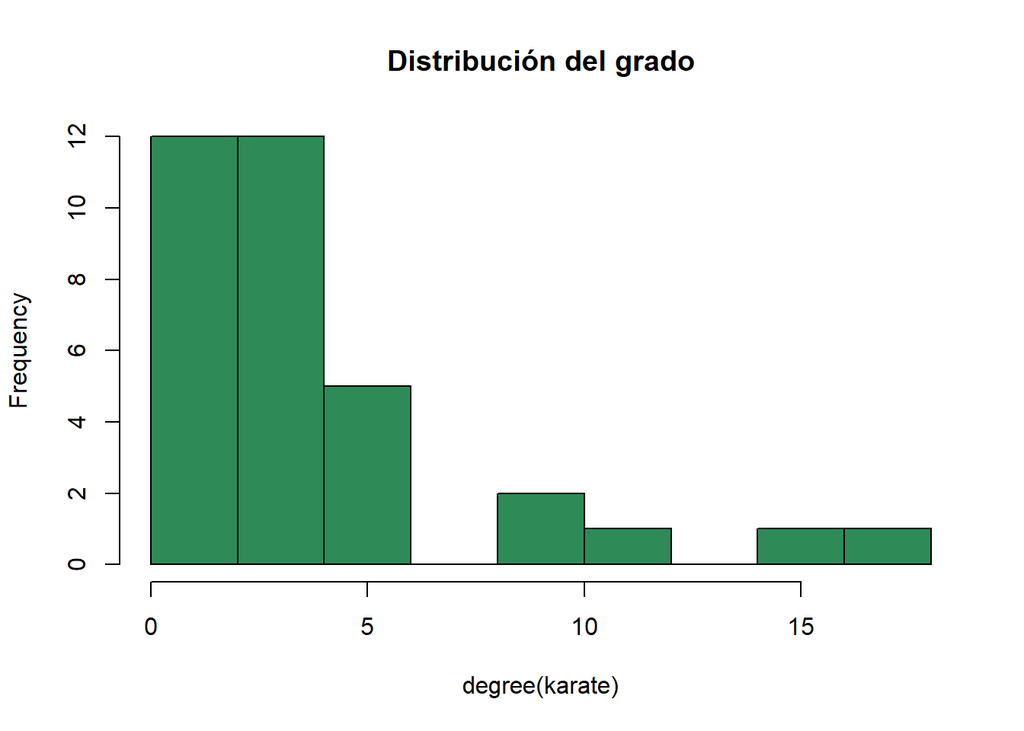

```r
#Gráfica
dist_con <- hist(degree(karate), col="seagreen", main = "Distribución del grado")
```

```r
dist_con
```

```
## $breaks
##  [1]  0  2  4  6  8 10 12 14 16 18
##
## $counts
## [1] 12 12  5  0  2  1  0  1  1
##
## $density
## [1] 0.17647059 0.17647059 0.07352941 0.00000000 0.02941176 0.01470588 0.00000000
## [8] 0.01470588 0.01470588
##
## $mids
## [1]  1  3  5  7  9 11 13 15 17
##
## $xname
## [1] "degree(karate)"
##
## $equidist
## [1] TRUE
##
## attr(,"class")
## [1] "histogram"
```

- Calcula el diámetro, la matriz de distancias y la distancia promedio

```r
# Diámetro
diameter (karate)
```

```
## [1] 5
```

```r
# Matriz de distancias
dist_mat <- distances (karate)
# Distancia promedio
mean_distance (karate)
```

```
## [1] 2.4082
```

- Encuentra la trayectoria de los nodos más alejados.

```r
sort( (get_diameter (karate)), decreasing = TRUE)
```

```
## + 6/34 vertices, from 3a12db3:
## [1] 33 17 15  6  3  1
```

```r
#Da la secuencia de nodos que forman el diámetro
```

- Existen nodos con coeficiente de clusterización 1. ¿Qué significa?

```r
transitivity (karate, type = "local")
```

```
##  [1] 0.1500000 0.3333333 0.2444444 0.6666667 0.6666667 0.5000000 0.5000000
##  [8] 1.0000000 0.5000000 0.0000000 0.6666667       NaN 1.0000000 0.6000000
## [15] 1.0000000 1.0000000 1.0000000 1.0000000 1.0000000 0.3333333 1.0000000
## [22] 1.0000000 1.0000000 0.4000000 0.3333333 0.3333333 1.0000000 0.1666667
## [29] 0.3333333 0.6666667 0.5000000 0.2000000 0.1969697 0.1102941
```

Los nodos con coeficiente de cluesterización igual a 1 demustran que cada uno de los nodos a los que está conectado también están conectados entre sí.

- Mide , con al menos tres medidas de centralidad, los nodos más importantes.

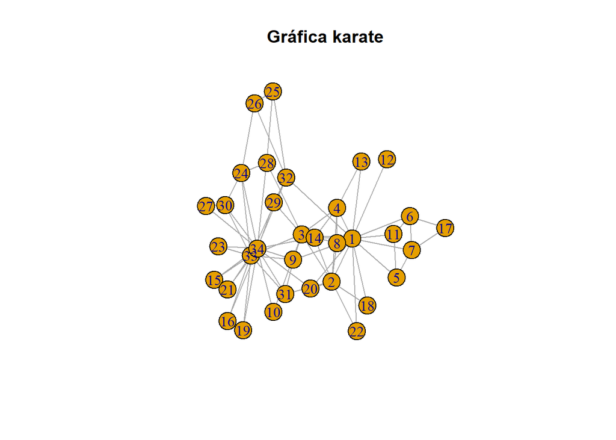

```r
# visualización de la gráfica
plot(karate, main = "Gráfica karate") #para saber seleccionar los hubs
```

```r
#Elijo sort para que calcule mayor a menor
head ( sort (degree(karate), decreasing = TRUE), 5)
```

```
## [1] 17 16 12 10  9
```

```r
head ( sort (betweenness(karate), decreasing = TRUE), 5)
```

```
## [1] 231.07143 160.55159  76.69048  75.85079  73.00952
```

```r
head ( sort (closeness(karate), decreasing = TRUE), 5)
```

```
## [1] 0.01724138 0.01694915 0.01666667 0.01639344 0.01562500
```

**Explica e interpreta tus resultados**.

2. **Amigues**

```r
#Cargar la red
g2 <- read.csv ("C:/Users/julie/OneDrive/Escritorio/R/Genómica Funcional/Tarea 4/Data/adjacency_matrix.csv")
rownames(g2)<-g2[,1]
g2 <- g2[,-1]
g2 <- as.matrix(g2)
diag(g2)<-0
red <- graph_from_adjacency_matrix(g2)
```

A partir de la red de amigues que vimos en clase, en su versión no ponderada, contesta lo siguiente:

- Escribe una función que calcule el número de amigos que tiene cualquier persona arbitraria y lo compare con el número de los amigos de estos.

```r
amigos_de_amigos <- function (persona) {
  sus_amigos <- neighbors(red, persona, mode = "out")
  num_amigos <- length(sus_amigos)
  #Del ejemplo en la práctica sapply(networks, function(g) transitivity(g, type = "global"))
  amigos_de_amigos <- sapply ( sus_amigos, function(ami) length(neighbors (red, ami, mode = "out")) )


  cat ("Amigos de la persona:", num_amigos, "\n")
  cat ("Amigos de sus amigos:", amigos_de_amigos, "\n")

}

#Comprobar la función
amigos_de_amigos("JULIETA")
```

```
## Amigos de la persona: 7
## Amigos de sus amigos: 7 3 6 9 5 3 16
```

- Escribe una función que te de la trayectoria más larga entre dos nodos arbitrarios de la red.

```r
trayectoria_larga <- function (persona1, persona2) {
  #Calcular los trayectos
  trayectos <- all_simple_paths (red, from = persona1, to =persona2, mode = "all" )
  #Añado all porque in y out no los calcula
  #Calcular la longitud de los paths
  long_trayectos <- sapply (trayectos, function (tray) length (tray) - 1 )
  #Añadí el -1 porque lo que da es el número de nodos, si se resta 1 da la conexión entre estos
  max_trayecto <- trayectos[[which.max(long_trayectos)]]
  #Trayectos guarda la secunia de nodos y long_trayectos la longitud
  max_long <- max(long_trayectos)

  cat("Máximo trayecto:", paste(max_trayecto, collapse = " -> "), "\n") #Colapse permite que se muestren en serie añadiendo la flecha -> hace más entendible el trayecto
  cat ("Longitud máxima:", max_long)

}

#trayectoria_larga ("JULIETA", "BLANCA")
```

- Encuentra las dos personas más populares.

```r
#Las personas más populares serían las que más personas consideran su amigo/a. Por lo que se calcula el grado en modo "in".
popularidades <- degree(red, mode = "in")
#Acomodar en función de su popularidad, de mayor a menor
sort(popularidades, decreasing = TRUE)
```

```
##  DANIELA     ZAID  ABRAHAM  MELISSA MICHELLE   XYMENA  ALONDRA     IVAN
##        9        9        8        8        8        8        6        6
##  JULIETA   BLANCA ESTRELLA   ISABEL   ANDRES   MIGUEL SANTIAGO TRINIDAD
##        6        5        5        5        4        4        4        4
##     LUIS    CARLA CRISTINA   NATALY   JIMENA
##        3        2        2        2        0
```

3. **Red PPI**

A partir de la red de interacción proteína-proteína (PPI) de la levadura que se encuentra en la bilbioteca `igraphdata` Elabora un script que conteste lo siguiente:

```r
#Supuse que la base de datos era la única llamada yeast en la guía de igraphdata
#https://cran.r-project.org/web/packages/igraphdata/igraphdata.pdf

#Cargar la libería
library(igraphdata)

#Cargar el dataset
data (yeast)
#Pide actualizar la base de datos
igraph::upgrade_graph(yeast)
```

```
## IGRAPH 65c41bb UN-- 2617 11855 -- Yeast protein interactions, von Mering et al.
## + attr: name (g/c), Citation (g/c), Author (g/c), URL (g/c), Classes
## | (g/x), name (v/c), Class (v/c), Description (v/c), Confidence (e/c)
## + edges from 65c41bb (vertex names):
##  [1] YLR197W--YDL014W YOR039W--YOR061W YDR473C--YPR178W YOR332W--YLR447C
##  [5] YER090W--YKL211C YDR394W--YGR232W YER021W--YPR108W YPR029C--YKL135C
##  [9] YIL106W--YGR092W YKL166C--YIL033C YGL026C--YKL211C YOR061W--YGL019W
## [13] YGL115W--YER027C YGL049C--YGR162W YDR394W--YOR117W YDL140C--YML010W
## [17] YLR291C--YKR026C YGR158C--YDL111C YDR328C--YDL132W YOL094C--YNL290W
## [21] YDR460W--YPR025C YBR154C--YOR341W YBR154C--YOR116C YIL062C--YKL013C
## [25] YBR154C--YOR207C YBR154C--YPR010C YER027C--YDR477W YLR291C--YGR083C
## + ... omitted several edges
```

- Encuentre qué tipo de distribución de conectividades tiene. Haz un ajuste en log-log para ver que tipo de distribución podría ser.

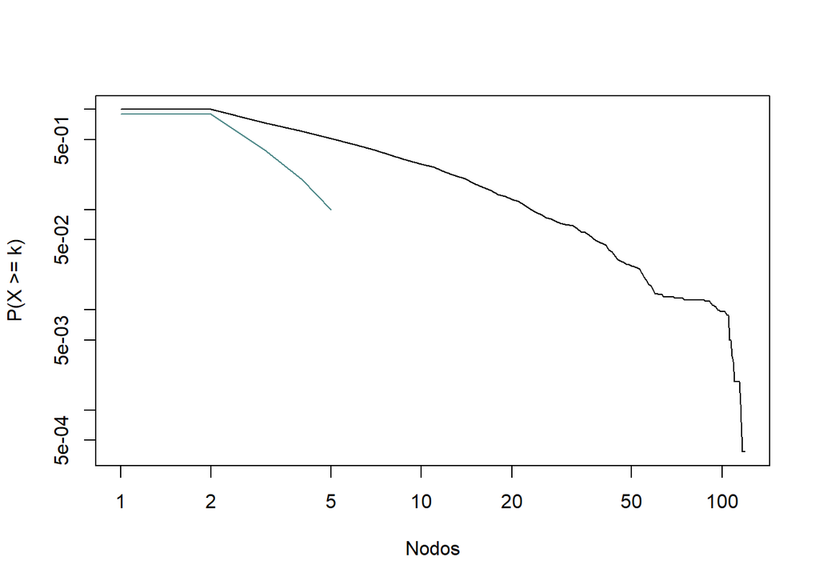

```r
#Código de: http://igraph.discourse.group/t/degree-distribution-method-clarification/522/3

d_yeast <- degree_distribution(yeast, cumulative=TRUE, mode="in")
d_yeast <- d_yeast[d_yeast > 0]


 dist = degree(g, mode="in")
 dd_1 = list();
 for (i in 1:max(dist)) {   #inicio de 1 para el log-log
   dd_1[i] = length(dist[dist >= i]) / length(dist);
 }

plot(d_yeast, log="xy", type="l", xlab="Nodos", ylab="P(X >= k)")
lines(1:max(dist), dd_1, col= "darkslategray4")
```

- Encuentra las diez proteínas más conectadas

```r
head ( sort (degree(yeast, mode = "total"), decreasing = TRUE), 10)
```

```
## YPR110C YPL131W YNL178W YIL021W YOL127W YJL063C YBR283C YLR378C YMR260C YBR251W
##     118     115     114     113     113     108     108     108     107     106
```

- Calcula el diámetro y promedio de las distancias

```r
diameter(yeast)
```

```
## [1] 15
```

```r
mean_distance (yeast)
```

```
## [1] 5.095629
```

- Crea una función que, a partir de eliminar al azar un nodo de la red genere el promedio d elas distancias después de eliminar $n=1,2,3,\ldots, 100$ nodos al azar

```r
#Función para deleciones sucesivas
delecion_sucesiva <- function (grafica, num_deleciones) {
  dist_inicial <-  mean_distance(grafica)
  dist_final <- num_deleciones
  graf_modif <- grafica

  for (i in 1:num_deleciones) {
    #Sample de los nodos, al azar
    #En vez de
    samp <- sample (1:(length (graf_modif)), 1, replace = FALSE)
    #deleciones
    graf_modif <- delete_vertices (graf_modif, samp)
    #Guardar deleciones
  }

  dist_final <- mean_distance(graf_modif)

  cat ("Distancia promedio inicial:", dist_inicial, "\n")
  cat ("Distancia promedio final:", dist_final)
}

y2 <- yeast
delecion_sucesiva (y2, 400)
```

```
## Distancia promedio inicial: 5.095629
## Distancia promedio final: 5.294031
```

- Crea una función que elimine las proteínas más conectadas y calcule el promedio de las distancias cada vez que se remueve un nodo.

```r
delecion_conect <- function (grafica, num_deleciones) {
  graf_modif <- grafica   #gráfica inicial para irle haciendo las iteraciones
  dist_inicial <- mean_distance(grafica)
  #Definir los nodos (proteínas) más conectadas según el degree total
  prot_conect <- degree(graf_modif, mode = "total")
  #elegir el nodo más conectado
  nodo_mas_conectado <- which.max(prot_conect)

  for (i in 1:num_deleciones) {
    graf_modif <- delete_vertices (graf_modif, nodo_mas_conectado)
  }

  dist_final <- mean_distance (graf_modif)

  cat ("Distancia promedio inicial:", dist_inicial, "\n")
  cat ("Distancia promedio final:", dist_final)
}

y3 <- yeast
delecion_conect(y3, 400)
```

```
## Distancia promedio inicial: 5.095629
## Distancia promedio final: 5.550046
```

- Calcula el promedio del coeficiente de clusterización. ¿Hay proteínas que tengan un coeficiente de clusterización de 1? Eso qué significa.

```r
#Promedio CC
y_cc <- transitivity(yeast,type = "local")
prom_cc <- mean(y_cc, na.rm = TRUE)
prom_cc
```

```
## [1] 0.3870165
```

```r
#Proteínas con CC = 1?
prot_cc <- (transitivity (yeast, type = "local"))
#Any patra que no salga toda la lista
any (prot_cc == 1) #Sí hay proteínas con CC = 1
```

```
## [1] TRUE
```

4. **Redes biológicas**

Ve a al [Network Repository](https://networkrepository.com/bn-mouse-visual-cortex-1.php) y descarga la red en formato lista de adyacencia. Explica que representam los nodos y las conectividades.

Escribe código que resuelva lo siguiente: - Cargue y genere una gráfica en `igraph`.

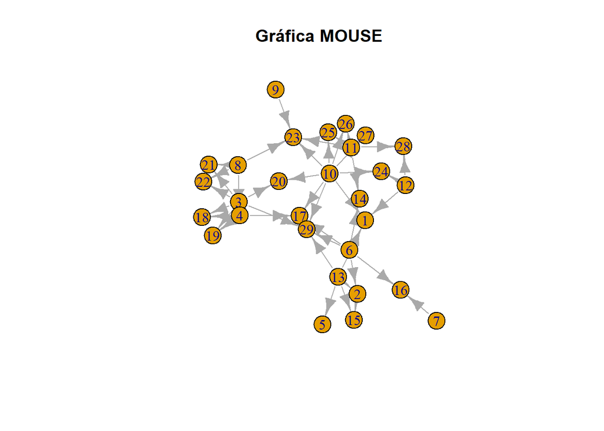

```r
#Cargar archivo edges

mouse <- read.graph("C:/Users/julie/OneDrive/Escritorio/R/Genómica Funcional/Tarea 4/Data/bn-mouse_visual-cortex_1.edges")
#Gráfica
plot (mouse, main = "Gráfica MOUSE")
```

- Genera la gráfica con todos los layouts disponibles.

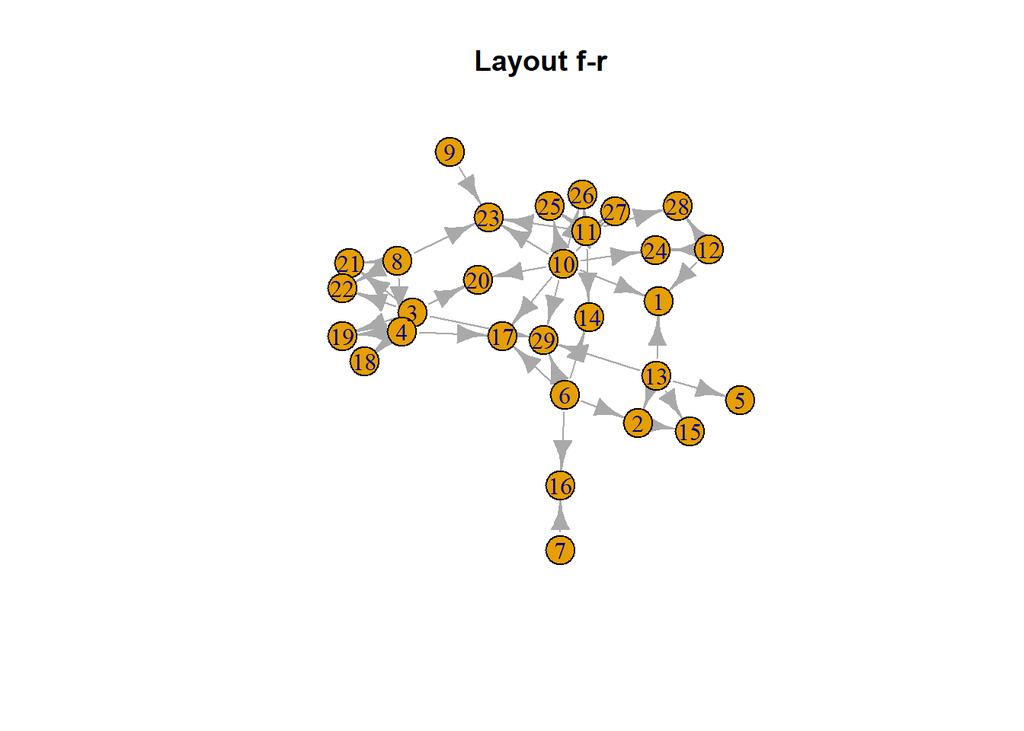

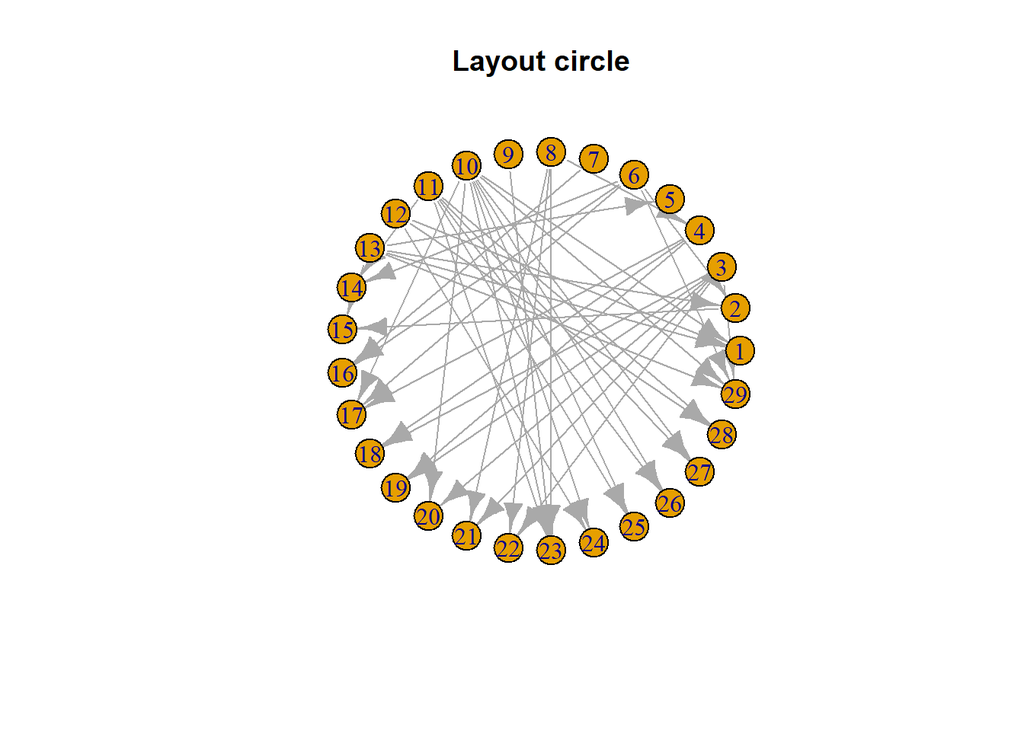

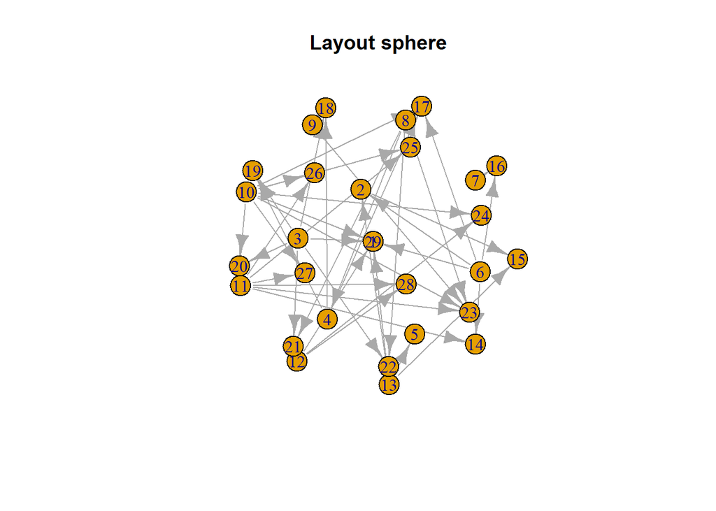

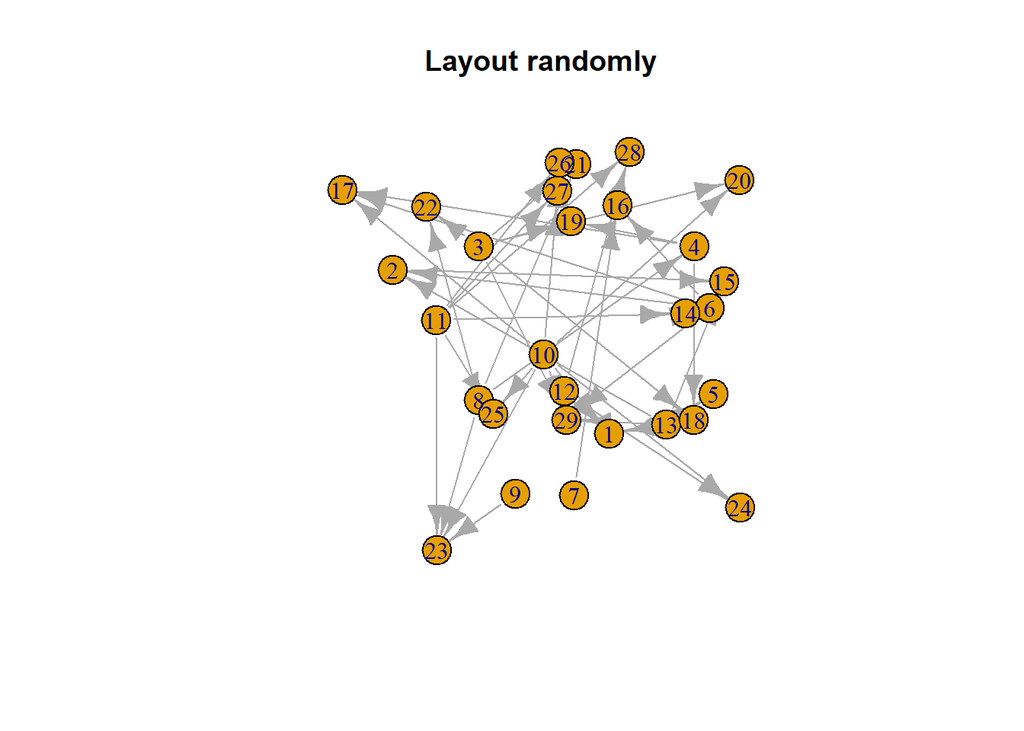

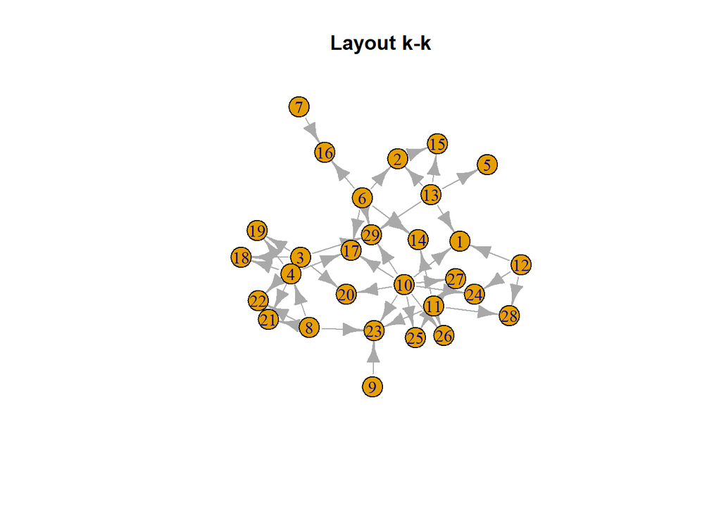

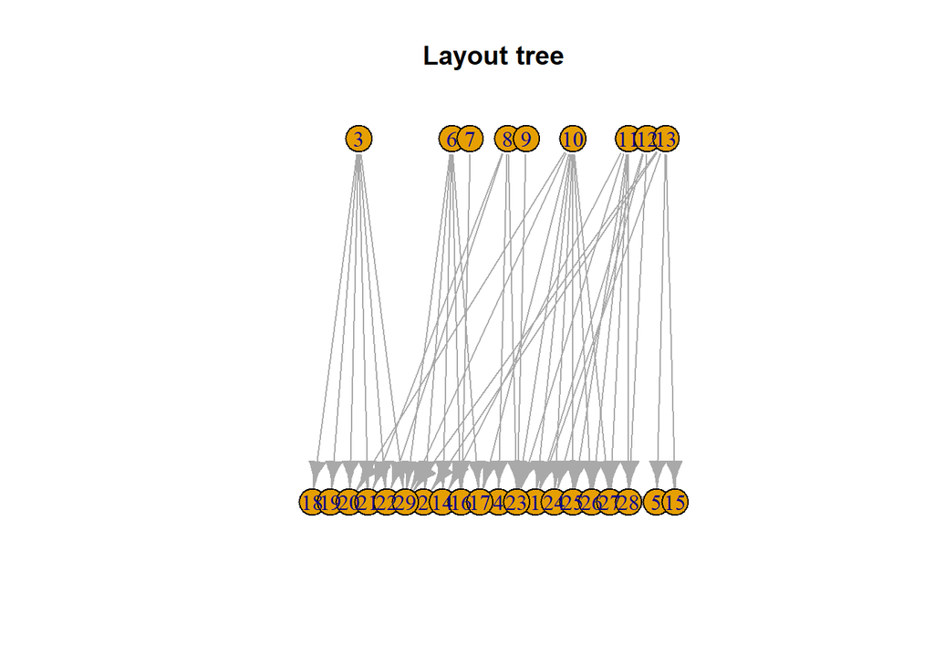

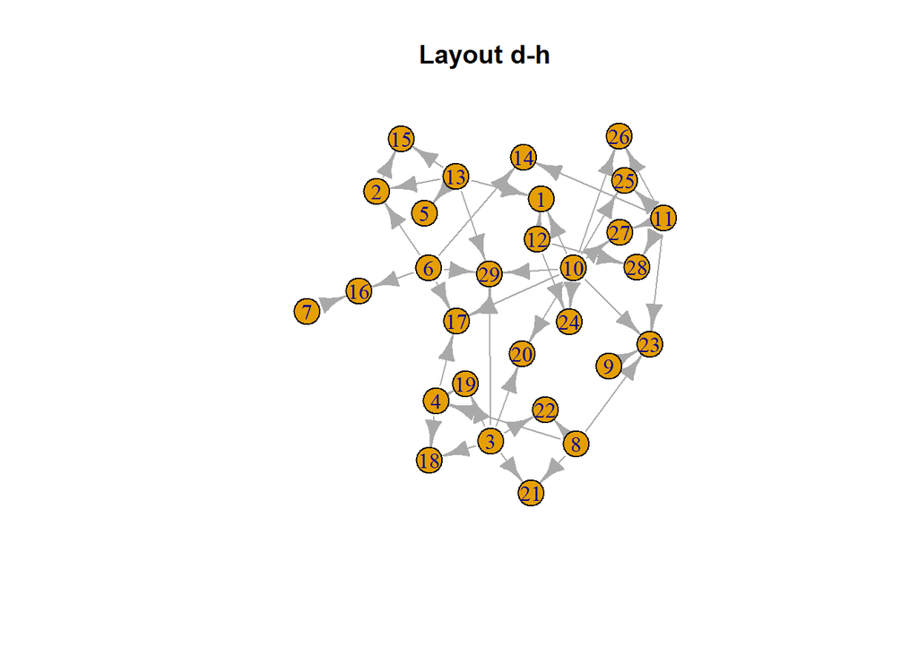

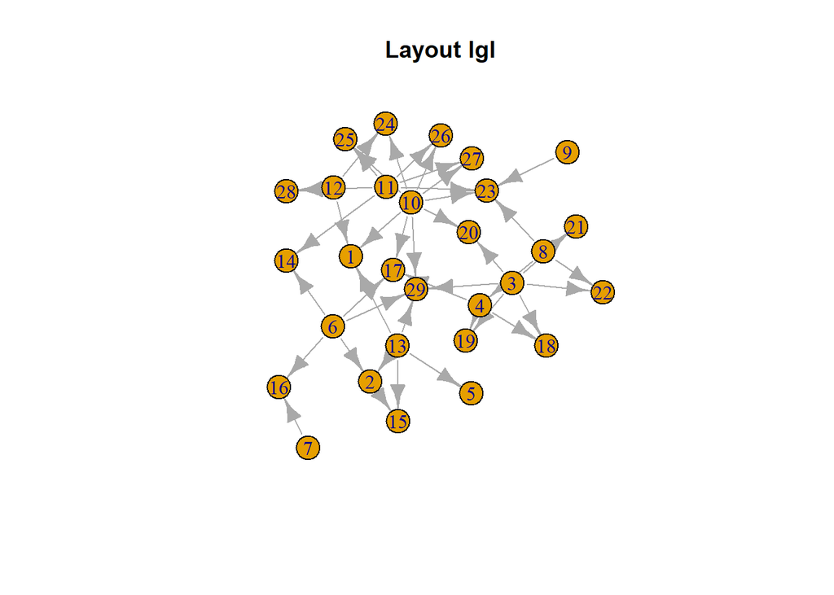

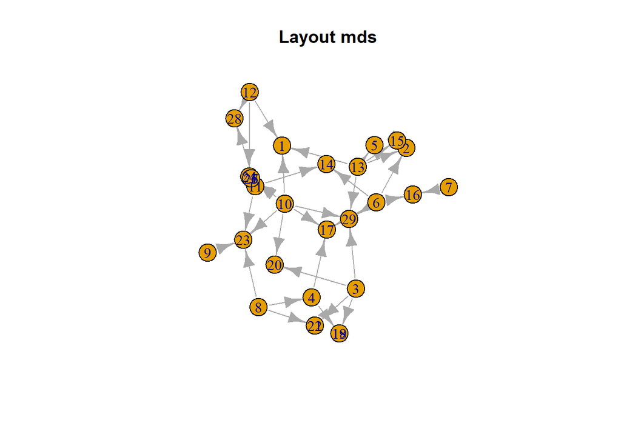

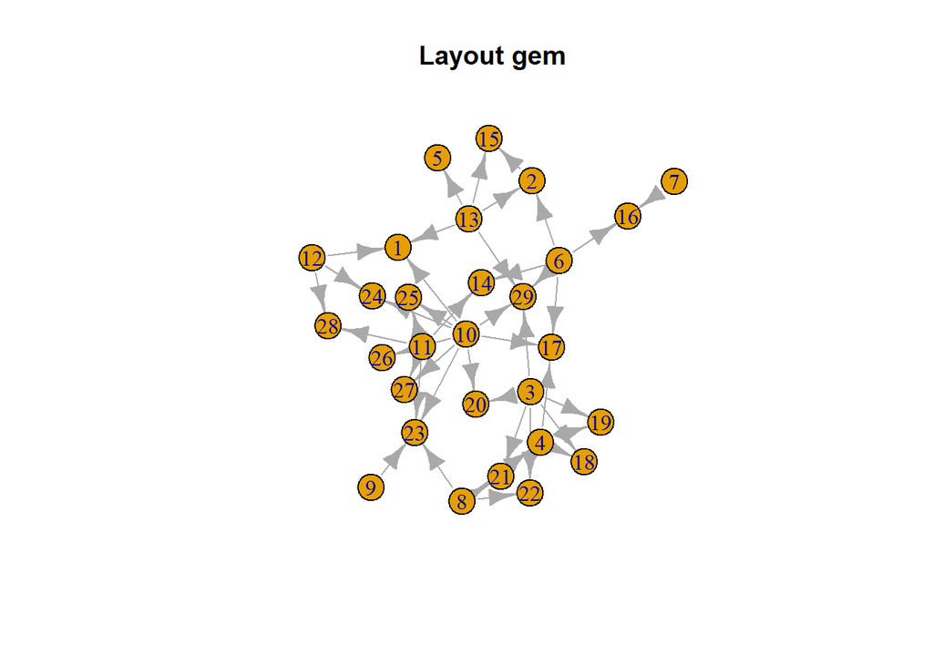

```r
#Calculo para cada layout
layouts <- list (
  layout_with_fr (mouse), layout_in_circle(mouse), layout_on_sphere(mouse),
  layout_randomly(mouse),layout_with_kk(mouse),layout_as_tree(mouse),layout_with_dh(mouse),
  layout_with_lgl(mouse),layout_with_mds(mouse),layout_with_gem(mouse) )



#Lista de nombres
nombre_layout <- c("f-r","circle","sphere", "randomly","k-k", "tree",
                   "d-h","lgl","mds","gem")

#ciclo for para graficar
for (i in 1:length(layouts)) {
  plot (mouse, layout = layouts[[i]],  #Doble corchete pq sino no funciona
        main = paste ("Layout", nombre_layout[i])) #paste porque cat imprime en consola
}
```